# Exercise 2.2: Complete, No, and Partial Pooling (Solution)

Henrik Singmann

January 2019 (updated: 2019-07-23)

# Task Description

One finding reported in the literature is that the weather influences ones subjective well-being. File `weather_wb.csv` contains simulated (i.e., fictitious) data from a study in which a random sample of 60 individuals (column `id`) were asked to report their subjective well being (column `swb`) at the end of each of 45 consecutive days. Note, the start date for each participant can be a different day and participants can come from different locations/climates. Subjective well-being was a composite score constructed from four individual items. Participants had to rate how “happy”, “joyful”, “sad”, and “angry” they felt on a scale from 0 to 10, and the last two items were reverse coded for the composite score. In addition, the data also contains the daily sun hours (column `sunh`) at the location the participant was during each day.

Your task is to analyse this data using no-pooling, at least one complete-pooling approach (ideally two different complete pooling approaches), and partial pooling using a linear mixed models (there also can be more than one partial pooling solution). The research goal is to answer the question if there is a relationship between the daily sun hours and the reported subjective well-being.

Do the different approaches agree in their conclusions? If not, what you think is the correct approach and why do you think the different approaches might provide a different answer? If you can, please add one figure for each of your analyses approaches to the results.

# Solution

### Load Data and Packages

Load packages and read data in.

```r
library("tidyverse")
library("cowplot")
theme_set(theme_bw(base_size = 12) +
            theme(legend.position="bottom",
                  panel.grid.major.x = element_blank(),
                  panel.grid.minor.x = element_blank()))
w <- read_csv("weather_wb.csv")
```

### Descriptive Statistics

Then let’s calculate some descriptives statistics. First, number of observations and participants

```r
w %>%
  group_by(id) %>%
  summarise(n = n()) %>%
  psych::describe()
```

|  | vars | n | mean | sd | median | trimmed | mad | min | max | range | skew | kurtosis | se |
| --- | --- | --- | --- | --- | --- | --- | --- | --- | --- | --- | --- | --- | --- |
| id | 1 | 60 | 30.5 | 17.46 | 30.5 | 30.5 | 22.24 | 1 | 60 | 59 | 0 | -1.26 | 2.25 |
| n | 2 | 60 | 45.0 | 0.00 | 45.0 | 45.0 | 0.00 | 45 | 45 | 0 | NaN | NaN | 0.00 |

Second, descriptive statistics where data is aggregated within participants:

```r
w %>%
  group_by(id) %>%
  summarise(mean_sunh = mean(sunh),
            mean_swb = mean(swb)) %>%
  select(-id) %>%
  psych::describe()
```

|  | vars | n | mean | sd | median | trimmed | mad | min | max | range | skew | kurtosis | se |
| --- | --- | --- | --- | --- | --- | --- | --- | --- | --- | --- | --- | --- | --- |
| mean_sunh | 1 | 60 | 5.09 | 2.27 | 4.97 | 5.08 | 3.12 | 1.14 | 8.84 | 7.71 | 0.03 | -1.38 | 0.29 |
| mean_swb | 2 | 60 | 7.01 | 0.96 | 7.09 | 7.06 | 0.92 | 4.32 | 8.79 | 4.47 | -0.50 | -0.10 | 0.12 |

This shows quite a considerable range in mean daily sun hours as well as mean subjective well-being.

Plot data by id (this incorrectly treats `id` as a numerical variable,).

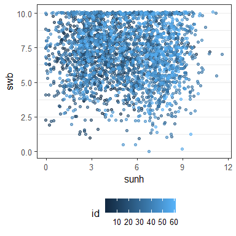

```r
## Rmarkdown settings: fig.width=4, fig.height=4, dpi=125
ggplot(w, aes(x = sunh, y = swb, color = id)) +
  geom_point(alpha = 0.6, position = position_jitter())
```

This does not show a very clear pattern. Not a very useful graph.

### No Pooling

Calculate no-pooling estimates for each participant and plot distribution of slopes. Add mean to slopes.

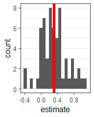

```r
no_all <- w %>%
  group_by(id) %>%
  do(broom::tidy(lm(swb ~ sunh, .)) )

no_slope <- no_all %>%
  filter(term == "sunh")
ggplot(no_slope, aes(estimate)) +
  geom_histogram(bins = 20) +
  geom_vline(aes(xintercept = mean(estimate)), col='red', size=2)
```

Calculate whether distribution of individual slopes differ from 0.

```r
summary(lm(estimate ~ 1, no_slope))
```

```
Call:
lm(formula = estimate ~ 1, data = no_slope)

Residuals:
     Min       1Q   Median       3Q      Max
-0.73795 -0.22441 -0.02029  0.16703  0.72640

Coefficients:
            Estimate Std. Error t value Pr(>|t|)
(Intercept)  0.31587    0.04046   7.806 1.16e-10 ***
---
Signif. codes:  0 ‘***’ 0.001 ‘**’ 0.01 ‘*’ 0.05 ‘.’ 0.1 ‘ ’ 1

Residual standard error: 0.3134 on 59 degrees of freedom
```

Proportion of slopes larger 0?

```r
mean(no_slope$estimate > 0)
```

```
[1] 0.8666667
```

Descriptive statistics of slope estimates (requires `psych` package):

```r
psych::describe(no_slope$estimate)
```

|  | vars | n | mean | sd | median | trimmed | mad | min | max | range | skew | kurtosis | se |
| --- | --- | --- | --- | --- | --- | --- | --- | --- | --- | --- | --- | --- | --- |
| X1 | 1 | 60 | 0.32 | 0.31 | 0.3 | 0.31 | 0.28 | -0.42 | 1.04 | 1.46 | 0.16 | -0.04 | 0.04 |

Can we plot all individual slopes on top of individual data?

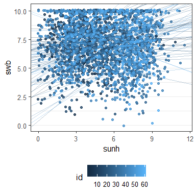

```r
no_plot <- no_all %>%
  select(id:estimate) %>%
  spread(term, estimate)

ggplot(w, aes(x = sunh, y = swb, color = id)) +
  geom_point(alpha = 0.8, position = position_jitter()) +
  geom_abline(data = no_plot, aes(slope = sunh, intercept = `(Intercept)`, color = id), alpha = 0.3)
```

Not really. Maybe only the slopes?

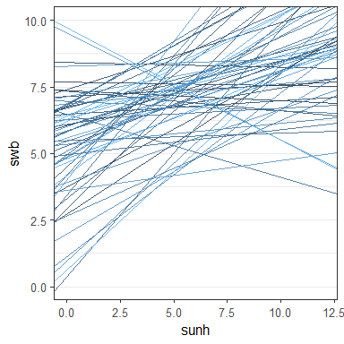

```r
no_plot <- no_all %>%
  select(id:estimate) %>%
  spread(term, estimate)

ggplot(w, aes(x = sunh, y = swb, color = id)) +
  geom_abline(data = no_plot, aes(slope = sunh,
                                  intercept = `(Intercept)`,
                                  color = id), alpha = 0.8) +
  xlim(0, 12) + ylim(0, 10) +
  theme(legend.position = "none")
```

Clearly better.

### Complete Pooling 1

Calculate complete pooling approach across all data points.

```r
cp1 <- lm(swb ~ sunh, w)
summary(cp1)
```

```
Call:
lm(formula = swb ~ sunh, data = w)

Residuals:
    Min      1Q  Median      3Q     Max
-6.9663 -1.4491  0.1145  1.5583  3.1418

Coefficients:
            Estimate Std. Error t value Pr(>|t|)
(Intercept)  7.13336    0.08955   79.66   <2e-16 ***
sunh        -0.02457    0.01585   -1.55    0.121
---
Signif. codes:  0 ‘***’ 0.001 ‘**’ 0.01 ‘*’ 0.05 ‘.’ 0.1 ‘ ’ 1

Residual standard error: 2.014 on 2698 degrees of freedom
Multiple R-squared:  0.0008895, Adjusted R-squared:  0.0005192
F-statistic: 2.402 on 1 and 2698 DF,  p-value: 0.1213
```

Add regression line to full data

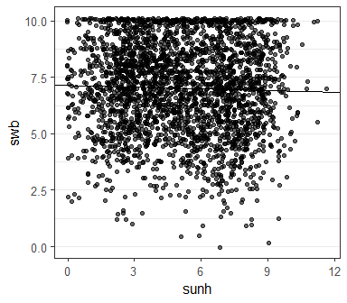

```r
ggplot(w, aes(x = sunh, y = swb)) +
  geom_point(alpha = 0.6, position = position_jitter()) +
  geom_abline(intercept = coef(cp1)[1], slope = coef(cp1)[2])
```

This looks like a zero relationship.

### Complete Pooling 2

```r
w_agg <- w %>%
  group_by(id) %>%
  summarise(swb = mean(swb),
            sunh = mean(sunh))
cp2 <- lm(swb ~ sunh, w_agg)
summary(cp2)
```

```
Call:
lm(formula = swb ~ sunh, data = w_agg)

Residuals:
     Min       1Q   Median       3Q      Max
-2.58671 -0.54899  0.07318  0.61886  1.72641

Coefficients:
            Estimate Std. Error t value Pr(>|t|)
(Intercept)  7.44803    0.30474  24.441   <2e-16 ***
sunh        -0.08636    0.05475  -1.577     0.12
---
Signif. codes:  0 ‘***’ 0.001 ‘**’ 0.01 ‘*’ 0.05 ‘.’ 0.1 ‘ ’ 1

Residual standard error: 0.9527 on 58 degrees of freedom
Multiple R-squared:  0.04113,   Adjusted R-squared:  0.0246
F-statistic: 2.488 on 1 and 58 DF,  p-value: 0.1201
```

Again no relationship. How does the slope look?

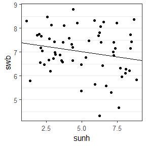

```r
ggplot(w_agg, aes(x = sunh, y = swb)) +
  geom_point() +
  geom_abline(intercept = coef(cp2)[1], slope = coef(cp2)[2])
```

That looks a bit more like there was something, but if anything negative. Which differs considerably from the no pooling approach.

### Partial Pooling

To fit the partial pooling model, we load `lme4`. We then estimate the model with a fixed effect for `sunh` and by-participant random intercept as well as by-participant random slopes for `sunh`.

```r
library("lme4")
mm1 <- lmer(swb ~ sunh + (sunh|id), w)
```

```
Model failed to converge with max|grad| = 0.00403895 (tol = 0.002, component 1)
```

```r
summary(mm1)
```

```
Linear mixed model fit by REML ['lmerMod']
Formula: swb ~ sunh + (sunh | id)
   Data: w

REML criterion at convergence: 10921.7

Scaled residuals:
    Min      1Q  Median      3Q     Max
-3.6876 -0.6540  0.0423  0.7449  2.6245

Random effects:
 Groups   Name        Variance Std.Dev. Corr
 id       (Intercept) 1.41392  1.1891
          sunh        0.02704  0.1644   -0.48
 Residual             3.10566  1.7623
Number of obs: 2700, groups:  id, 60

Fixed effects:
            Estimate Std. Error t value
(Intercept)  5.93046    0.22371  26.510
sunh         0.21978    0.03753   5.857

Correlation of Fixed Effects:
     (Intr)
sunh -0.754
convergence code: 0
Model failed to converge with max|grad| = 0.00403895 (tol = 0.002, component 1)
```

In the mixed model, the estimated slope of `sunh` is clearly positive and more similar to the no pooling than the complete pooling estimate.

Let us plot this model.

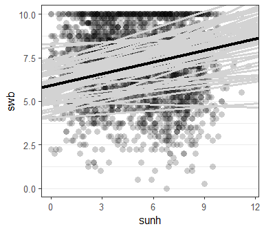

```r
rnd_coefs <- as_tibble(coef(mm1)$id)

ggplot(data = w, aes(x = sunh, y = swb)) +
  geom_point(alpha = 0.2, pch = 16, size = 3) +
  geom_abline(data = rnd_coefs, aes_string(intercept = "`(Intercept)`",
                                     slope = "sunh"),
              color = "lightgrey", size = 1.2) +
  geom_abline(intercept = fixef(mm1)[1], slope = fixef(mm1)[2], size = 1.5)
```

### Explaining the Differences

Our three different pooling approaches and three model produce three different results. Using complete pooling, we find essentially no evidence for a relationship between daily sun hours and subjective well-being. In contrast, for both the partial pooling and the no pooling approach we find evidence for a positive relationship between those variables.

```r
mean(no_slope$estimate)
```

```
[1] 0.3158713
```

```r
coef(cp2)[2]
```

```
       sunh
-0.08636315
```

```r
(mean(no_slope$estimate) - coef(cp2)[2]) / 2
```

```
     sunh
0.2011172
```

```r
fixef(mm1)[2]
```

```
     sunh
0.2197779
```

How can we explain these differences? The reason for these differences is that diffeent approaches answer different research question. Let us look at the no pooling and complete pooling approaches first. The complete pooling approaches are telling us whether a relationship exists across participants and also across places with different climates. Consider for example that one participant lives in a rather cold climate with generally few sun hours whereas another lives in a comparatively warm climate with more sun hours. Assuming that the difference in daily sun hours between participants is larger then the difference across days within participants, the complete pooling approaches would tell us whether a relationship in well-being exists across those participants. Is the person living in the cold climate less happy than the person in the warm climate?

In contrast, the no pooling approach tests whether this relationship exists within each participant and thus within the same climate. Does your subjective well-being fluctuate with the number of daily sun hours that are typical for where you live?

Both research questions are of course valid. Nevertheless, I feel that in the present case the more interesting one is the one on the individual-level, at least from a psychological perspective. And if this is indeed the research question one is interested in, using the complete pooling approach is clearly false. Otherwise one would commit the so-called [*ecological fallacy*](https://en.wikipedia.org/wiki/Ecological_fallacy). More specifically, the ecological fallacy is committed if individual-level inferences are drawn based on group-level data. Likewise, the pattern found here exhibits [*Simpson’s paradox*](https://en.wikipedia.org/wiki/Simpson%27s_paradox): Whereas on the individual-level we clearly see a positive relationship for almost all participants, this relationship is absent on the group-level. Another way to put it is to say that the complete pooling approaches exhibit an *aggregation bias*.

So what is happening in the partial poooling approach? The partial pooling approach used so far attempts to strike a balance between both questions and is therefore somewhere in the middle. This seems to be somewhat undesirable. As described before, the individual-difference questions seems preferrable here.

How can we then get this question out of the partial pooling model? For this, we need to remove the between-participant differences in daily sun hours from the daily sun hour. This can be done by creating a a variable that only contains the relative daily sun hour. Specifically, we subtract the individual-participant mean sun hours from the daily sun hours. This new variable, `sunh_pmc` (= person mean centred), then is 0 for each individual’s idiosyncratic mean sun hour and a value of 1 represent one more sun hour than usual. We also retain the individual-mean sun hours in variable `sunh_pm` (= person mean).

```r
w <- w %>%
  group_by(id) %>%
  mutate(sunh_pm = mean(sunh),
         sunh_pmc = sunh - mean(sunh)) %>%
  ungroup
```

We then fit a new mixed with our two new sun hour variables, the person mean centered sun hours and the person mean sun hours.

```r
mm2 <- lmer(swb ~ sunh_pmc + sunh_pm + (sunh_pmc|id), w)
summary(mm2)
```

```
Linear mixed model fit by REML ['lmerMod']
Formula: swb ~ sunh_pmc + sunh_pm + (sunh_pmc | id)
   Data: w

REML criterion at convergence: 10896.4

Scaled residuals:
    Min      1Q  Median      3Q     Max
-3.7679 -0.6631  0.0400  0.7417  2.6335

Random effects:
 Groups   Name        Variance Std.Dev. Corr
 id       (Intercept) 0.83876  0.9158
          sunh_pmc    0.02017  0.1420   0.01
 Residual             3.10272  1.7615
Number of obs: 2700, groups:  id, 60

Fixed effects:
            Estimate Std. Error t value
(Intercept)  7.44805    0.30474  24.441
sunh_pmc     0.31180    0.03978   7.838
sunh_pm     -0.08637    0.05475  -1.577

Correlation of Fixed Effects:
         (Intr) snh_pmc
sunh_pmc  0.002
sunh_pm  -0.915  0.000
```

This model now provides answers to both questions. Within-participants an increase in daily sun hours is associated with an increase in subjective well being with a slope of 0.31. However, across individuals the effects is considerably smaller and slightly negative (however, this effect seems unreliable relative to its standard error).

Let us plot this model as well:

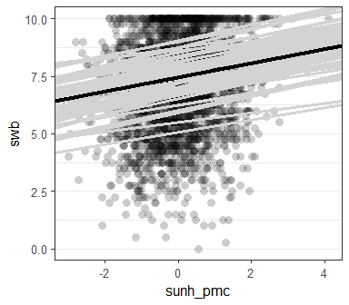

```r
rnd_coefs <- as_tibble(coef(mm2)$id)

ggplot(data = w, aes(x = sunh_pmc, y = swb)) +
  geom_point(alpha = 0.2, pch = 16, size = 3) +
  geom_abline(data = rnd_coefs, aes_string(intercept = "`(Intercept)`",
                                     slope = "sunh_pmc"),
              color = "lightgrey", size = 1.2) +
  geom_abline(intercept = fixef(mm2)[1], slope = fixef(mm2)[2], size = 1.5)
```

The difference between the final partial pooling model `mm2` and the no pooling estimate is whether or not we want hierarchical shrinkage. Should we assume that we do not really have enough data to estimate the individual level relationships reliable on their own and/or is it reasonable to assume that the individual-level correlations come from a normal distribution? If either or both of those is the case, we should probably prefer the partial pooling (i.e., mixed) model to the no pooling approach.

Please note that person-mean centering is often necessary when we are interested in within-subjects effect. To understand why in more detail, I highly recommend to study the excellent paper by Wang and Maxwell (2015) discussing this in detail. The full reference is:

Wang, L., & Maxwell, S. E. (2015). On disaggregating between-person and within-person effects with longitudinal data using multilevel models. *Psychological Methods*, 20(1), 63–83. https://doi.org/10.1037/met0000030

# Simulation Code

The following is the code used for simulating the data. As can be seen, the true mean correlation is 0.2.

```r
library("tidyverse")
library("psych")

set.seed(66)

total_N <- 60                 ## Number of participants

N <- 45                       ## number of observations per participant
R <- 0.2                      ## mean correlation in population
Rz <- fisherz(R)

indiv_R <- fisherz2r(rnorm(total_N, Rz, 0.07))

mus_sunh <- runif(total_N, 1, 9)
mus_swb <- rnorm(total_N, 7, 1)

SD <- c(2, 1)              ## population SD

## function only works for bivariate data
gen_correlated_vars <- function(N, R, MU, SD, empirical = FALSE) {
  cor_mat <- matrix(c(1,R,R,1), ncol = 2)
  cov_mat <- cor_mat * tcrossprod(SD)
  ## 'MASS::mvrnorm' uses function mvrnorm from package MASS:
  d <- MASS::mvrnorm(n = N,
                     mu = MU,
                     Sigma = cov_mat,
                     empirical = empirical) ## TRUE ensures correlation is true in sample
  colnames(d) <- c("swb", "sunh")
  d <- as_tibble(d)
  d$swb <- round(d$swb/0.25)*0.25
  d$swb <- ifelse(d$swb > 10, 10,
                  ifelse(d$swb < 0, 0, d$swb))
  d$sunh <- round(d$sunh, 1)
  return(d)
}


dl <- vector("list", total_N)

for (i in seq_len(total_N)) {
  dl[[i]] <- gen_correlated_vars(N = N, R = indiv_R[i],
                                 MU = c(mus_swb[i], mus_sunh[i]), SD = SD)
  dl[[i]]$id <- i
}

d <- bind_rows(dl)
d <- d %>%
  mutate(sunh = ifelse(sunh < 0, 0, sunh))

cor(d$swb, d$sunh)

GGally::ggpairs(d, columns = 1:2, diag = list(continuous = "barDiag"))

ggplot(d, aes(swb)) +
  geom_bar()

d %>%
  select(id, sunh, swb) %>%
  write_csv("weather_wb.csv")
```